# 台北市危老建築與都市更新的賽跑：危建最多的地區，都更有在追趕嗎？

R 語言資料分析

2026-05-09

## 1 研究問題

台北市同時面對兩種老舊建物風險：一類是被列管的地震危險建築物，另一類是海砂屋。都市更新理論上應該是處理老舊建物與居住風險的重要工具，但案件是否集中在危建較多的行政區，仍需要用資料檢查。

本報告以行政區為比較單位，將「地震危險建築物」與「海砂屋」合併為危建壓力，再用「都市更新案件數 / 危建總數」估算都更追趕率。這個指標不是因果推論，而是用來觀察各區危建壓力與都更案件量是否大致對得上。

## 2 套件載入

以下程式碼載入 API 呼叫、資料整理、視覺化、表格輸出與座標格式化所需套件。

```r
library(httr2)
library(dplyr)
library(tidyr)
library(readr)
library(ggplot2)
library(knitr)
library(scales)
```

## 3 資料導入

以下程式碼設定本機 FastAPI 端點，並以 `httr2` 呼叫三份資料。執行前請先確認後端服務已啟動於 `http://localhost:8000`。

```r
base_url <- "http://localhost:8000"

earthquake_url <- paste0(base_url, "/api/earthquake-buildings")
chloride_url <- paste0(base_url, "/api/chloride-ionized-concrete")
urban_update_url <- paste0(base_url, "/api/urban-update")
```

以下程式碼呼叫 API，並只保留本研究會使用的欄位。都市更新 API 內含較大的 `records` 欄位，這裡不納入分析表，以免 HTML 報告被大量座標資料淹沒。

```r
earthquake_response <- request(earthquake_url) |>
  req_perform() |>
  resp_body_json(simplifyVector = TRUE)

chloride_response <- request(chloride_url) |>
  req_perform() |>
  resp_body_json(simplifyVector = TRUE)

urban_update_response <- request(urban_update_url) |>
  req_perform() |>
  resp_body_json(simplifyVector = TRUE)

earthquake_raw <- as.data.frame(earthquake_response$result$results) |>
  select(id, county, district, building_location, note)

chloride_raw <- as.data.frame(chloride_response$result$results) |>
  select(id, county, district, building_name, purpose, organizer)

urban_update_raw <- as.data.frame(urban_update_response$data) |>
  select(districts, record_count)
```

以下程式碼印出地震危險建築物資料前六筆與資料筆數。

```r
kable(
  head(earthquake_raw),
  caption = paste0("地震危險建築物資料前六筆；原始筆數：", comma(nrow(earthquake_raw)), " 筆")
)
```

地震危險建築物資料前六筆；原始筆數：36 筆

| id | county | district | building_location | note |
| --- | --- | --- | --- | --- |
| 1 | 臺北市 | 士林區 | 天母北路87巷22弄2、4、6號； 87巷16至22號1至5樓 | 921黃單 |
| 2 | 臺北市 | 士林區 | 天母東路105巷1號3號地下室 | 921黃單 |
| 3 | 臺北市 | 士林區 | 延平北路五段213巷17至33之1號 | 921黃單 |
| 4 | 臺北市 | 大同區 | 敦煌路165號2樓 | 921黃單 |
| 5 | 臺北市 | 中山區 | 吉林路221至223號 | 921黃單 |
| 6 | 臺北市 | 中山區 | 長春路346號 | 921黃單 |

以下程式碼印出海砂屋資料前六筆與資料筆數。

```r
kable(
  head(chloride_raw),
  caption = paste0("海砂屋資料前六筆；原始筆數：", comma(nrow(chloride_raw)), " 筆")
)
```

海砂屋資料前六筆；原始筆數：12 筆

| id | county | district | building_name | purpose | organizer |
| --- | --- | --- | --- | --- | --- |
| 1 | 臺北市 | 南港區 | 忠孝院區醫療大樓行政大樓 | 醫院 | 臺北市政府衛生局(臺北市立聯合醫院) |
| 2 | 臺北市 | 信義區 | 松德院區第ㄧ院區醫療大樓 | 醫院 | 臺北市政府衛生局(臺北市立聯合醫院) |
| 3 | 臺北市 | 信義區 | 松德院區第五院區醫療大樓 | 醫院 | 臺北市政府衛生局(臺北市立聯合醫院) |
| 4 | 臺北市 | 中正區 | 和平婦幼院區 (和平)醫療大樓 | 醫院 | 臺北市政府衛生局(臺北市立聯合醫院) |
| 5 | 臺北市 | 士林區 | 永福之家 | 教養機構 | 臺北市政府社會局 臺北市立陽明教養院 |
| 6 | 臺北市 | 北投區 | 致中樓及致和樓 | 老人安養暨長期照顧機構 | 臺北市政府社會局 臺北市立浩然敬老院 |

以下程式碼印出都市更新資料前六筆與資料筆數。

```r
kable(
  head(urban_update_raw),
  caption = paste0("都市更新資料前六筆；原始筆數：", comma(nrow(urban_update_raw)), " 筆")
)
```

都市更新資料前六筆；原始筆數：17 筆

| districts | record_count |
| --- | --- |
| 內湖區 | 93 |
| 士林區 | 141 |
| 中山區 | 197 |
| 士林區,北投區 | 1 |
| 松山區 | 147 |
| 大安區 | 120 |

## 4 資料清理

清理重點有三個。第一，統一「台／臺」用字，避免同一行政區被分成兩類。第二，移除行政區缺漏或空白的資料，因為本研究的所有比較都依賴行政區。第三，都市更新資料若出現跨區案件，例如「士林區,北投區」，會拆成兩筆，代表該案件同時納入兩個行政區的案件量。

以下程式碼建立名稱標準化函數，統一「臺／台」並去除前後空白。

```r
normalize_name <- function(x) {
  x <- as.character(x)
  x <- gsub("臺", "台", x)
  trimws(x)
}
```

以下程式碼清理地震危險建築物資料：限定台北市、移除無行政區資料，並以 `id` 去除重複紀錄。

```r
earthquake_clean <- earthquake_raw |>
  mutate(
    county = normalize_name(county),
    district = normalize_name(district)
  ) |>
  filter(
    county == "台北市",       # 研究範圍限定台北市，避免其他縣市干擾比較
    !is.na(district),         # district 是後續合併鍵，缺漏會導致無法分區
    district != ""            # 空白行政區沒有分析意義
  ) |>
  distinct(id, .keep_all = TRUE) # 同一 id 重複時只計一次，避免高估危建數

kable(
  head(earthquake_clean),
  caption = paste0("清理後地震危險建築物前六筆；清理後筆數：", comma(nrow(earthquake_clean)), " 筆")
)
```

清理後地震危險建築物前六筆；清理後筆數：36 筆

| id | county | district | building_location | note |
| --- | --- | --- | --- | --- |
| 1 | 台北市 | 士林區 | 天母北路87巷22弄2、4、6號； 87巷16至22號1至5樓 | 921黃單 |
| 2 | 台北市 | 士林區 | 天母東路105巷1號3號地下室 | 921黃單 |
| 3 | 台北市 | 士林區 | 延平北路五段213巷17至33之1號 | 921黃單 |
| 4 | 台北市 | 大同區 | 敦煌路165號2樓 | 921黃單 |
| 5 | 台北市 | 中山區 | 吉林路221至223號 | 921黃單 |
| 6 | 台北市 | 中山區 | 長春路346號 | 921黃單 |

以下程式碼清理海砂屋資料：限定台北市、移除無行政區資料，並以 `id` 去除重複紀錄。

```r
chloride_clean <- chloride_raw |>
  mutate(
    county = normalize_name(county),
    district = normalize_name(district)
  ) |>
  filter(
    county == "台北市",       # 只分析台北市資料，讓三份資料的空間範圍一致
    !is.na(district),         # 行政區缺漏時無法與其他資料合併
    district != ""            # 移除空白行政區，避免產生無名稱分類
  ) |>
  distinct(id, .keep_all = TRUE) # 同一 id 重複時只保留一筆

kable(
  head(chloride_clean),
  caption = paste0("清理後海砂屋前六筆；清理後筆數：", comma(nrow(chloride_clean)), " 筆")
)
```

清理後海砂屋前六筆；清理後筆數：12 筆

| id | county | district | building_name | purpose | organizer |
| --- | --- | --- | --- | --- | --- |
| 1 | 台北市 | 南港區 | 忠孝院區醫療大樓行政大樓 | 醫院 | 臺北市政府衛生局(臺北市立聯合醫院) |
| 2 | 台北市 | 信義區 | 松德院區第ㄧ院區醫療大樓 | 醫院 | 臺北市政府衛生局(臺北市立聯合醫院) |
| 3 | 台北市 | 信義區 | 松德院區第五院區醫療大樓 | 醫院 | 臺北市政府衛生局(臺北市立聯合醫院) |
| 4 | 台北市 | 中正區 | 和平婦幼院區 (和平)醫療大樓 | 醫院 | 臺北市政府衛生局(臺北市立聯合醫院) |
| 5 | 台北市 | 士林區 | 永福之家 | 教養機構 | 臺北市政府社會局 臺北市立陽明教養院 |
| 6 | 台北市 | 北投區 | 致中樓及致和樓 | 老人安養暨長期照顧機構 | 臺北市政府社會局 臺北市立浩然敬老院 |

以下程式碼清理都市更新資料：統一行政區名稱、拆開跨區案件，並彙總各區案件數。

```r
urban_update_clean <- urban_update_raw |>
  transmute(
    district = normalize_name(districts),
    record_count = as.numeric(record_count)
  ) |>
  separate_rows(district, sep = "[,，、/]+") |>
  mutate(district = normalize_name(district)) |>
  filter(
    !is.na(district),         # 行政區是與危建資料合併的共同欄位
    district != "",           # 空白行政區無法進行行政區層級比較
    !is.na(record_count)      # 案件數缺漏時無法計算追趕率
  ) |>
  group_by(district) |>
  summarise(
    都更案件數 = sum(record_count, na.rm = TRUE), # 跨區案件會計入每個涉及行政區
    .groups = "drop"
  )

kable(
  head(urban_update_clean),
  caption = paste0("清理後都市更新資料前六筆；行政區數：", comma(nrow(urban_update_clean)), " 區")
)
```

清理後都市更新資料前六筆；行政區數：12 區

| district | 都更案件數 |
| --- | --- |
| 中山區 | 199 |
| 中正區 | 77 |
| 信義區 | 157 |
| 內湖區 | 95 |
| 北投區 | 141 |
| 南港區 | 81 |

## 5 描述性統計

以下程式碼計算各行政區的地震危建數、海砂屋數與危建總數，並用 `kable` 輸出排序後的表格。

```r
earthquake_count <- earthquake_clean |>
  count(district, name = "地震危建數")

chloride_count <- chloride_clean |>
  count(district, name = "海砂屋數")

hazard_summary <- full_join(earthquake_count, chloride_count, by = "district") |>
  mutate(
    地震危建數 = replace_na(地震危建數, 0),
    海砂屋數 = replace_na(海砂屋數, 0),
    危建總數 = 地震危建數 + 海砂屋數,
    危建占比 = 危建總數 / sum(危建總數) * 100
  ) |>
  arrange(desc(危建總數), district)

kable(
  hazard_summary,
  caption = "台北市各行政區危險建築數量統計",
  col.names = c("行政區", "地震危建數", "海砂屋數", "危建總數", "危建占比（%）"),
  digits = 1,
  align = "lrrrr"
)
```

台北市各行政區危險建築數量統計

| 行政區 | 地震危建數 | 海砂屋數 | 危建總數 | 危建占比（%） |
| --- | --- | --- | --- | --- |
| 北投區 | 8 | 1 | 9 | 18.8 |
| 信義區 | 6 | 2 | 8 | 16.7 |
| 士林區 | 5 | 2 | 7 | 14.6 |
| 中山區 | 4 | 2 | 6 | 12.5 |
| 內湖區 | 4 | 0 | 4 | 8.3 |
| 文山區 | 2 | 1 | 3 | 6.2 |
| 松山區 | 2 | 1 | 3 | 6.2 |
| 中正區 | 1 | 1 | 2 | 4.2 |
| 南港區 | 0 | 2 | 2 | 4.2 |
| 萬華區 | 2 | 0 | 2 | 4.2 |
| 大同區 | 1 | 0 | 1 | 2.1 |
| 大安區 | 1 | 0 | 1 | 2.1 |

上表按危建總數降冪排序，呈現出兩個層次的觀察。其一，危建分布並不均勻：北部行政區（北投、士林）的列管壓力明顯高於東側（內湖、南港）與南端（文山）。其二，地震危建與海砂屋的高列管區並不完全重疊——海砂屋多見於中山、南港等區，與地震危建的北側分布有所差異。因此後續以「危建總數」做為彙整指標時，需留意它代表的是兩類建物的累加，而非單一現象。

## 6 合併分析

以下程式碼以 `district` 做 `full_join`，合併三份資料，並計算 `危建總數 = 地震危建數 + 海砂屋數` 與 `都更追趕率 = 都更案件數 / 危建總數 * 100`。

```r
analysis_data <- earthquake_count |>
  full_join(chloride_count, by = "district") |>
  full_join(urban_update_clean, by = "district") |>
  mutate(
    地震危建數 = replace_na(地震危建數, 0),
    海砂屋數 = replace_na(海砂屋數, 0),
    都更案件數 = replace_na(都更案件數, 0),
    危建總數 = 地震危建數 + 海砂屋數,
    都更追趕率 = if_else(
      危建總數 > 0,
      都更案件數 / 危建總數 * 100,
      NA_real_
    ),
    都更缺口 = 都更案件數 - 危建總數
  ) |>
  arrange(desc(危建總數), district)

kable(
  analysis_data,
  caption = "台北市危建與都市更新整合分析",
  col.names = c("行政區", "地震危建數", "海砂屋數", "都更案件數", "危建總數", "都更追趕率（%）", "都更缺口"),
  digits = 1,
  align = "lrrrrrr"
)
```

台北市危建與都市更新整合分析

| 行政區 | 地震危建數 | 海砂屋數 | 都更案件數 | 危建總數 | 都更追趕率（%） | 都更缺口 |
| --- | --- | --- | --- | --- | --- | --- |
| 北投區 | 8 | 1 | 141 | 9 | 1566.7 | 132 |
| 信義區 | 6 | 2 | 157 | 8 | 1962.5 | 149 |
| 士林區 | 5 | 2 | 143 | 7 | 2042.9 | 136 |
| 中山區 | 4 | 2 | 199 | 6 | 3316.7 | 193 |
| 內湖區 | 4 | 0 | 95 | 4 | 2375.0 | 91 |
| 文山區 | 2 | 1 | 69 | 3 | 2300.0 | 66 |
| 松山區 | 2 | 1 | 148 | 3 | 4933.3 | 145 |
| 中正區 | 1 | 1 | 77 | 2 | 3850.0 | 75 |
| 南港區 | 0 | 2 | 81 | 2 | 4050.0 | 79 |
| 萬華區 | 2 | 0 | 151 | 2 | 7550.0 | 149 |
| 大同區 | 1 | 0 | 64 | 1 | 6400.0 | 63 |
| 大安區 | 1 | 0 | 120 | 1 | 12000.0 | 119 |

合併表立即顯示一個本研究核心的單位落差：每個行政區的都更案件數都明顯高於該區危建總數。「都更追趕率」與「都更缺口」雖以兩者相除或相減而得，但兩個原始數的單位並不對等——一件都更案件可涵蓋多棟建物，並橫跨從計畫核定、施工中到完工的不同程序階段；而危建總數是現行的個別建物列管數。因此後續的追趕率排名應放在相對尺度上理解，不可解讀為「都更已處理 X% 的危建」。

以下程式碼建立報告摘要與結論會使用的排名資料。

```r
top_hazard <- analysis_data |>
  filter(危建總數 == max(危建總數, na.rm = TRUE)) |>
  slice(1)

lowest_catchup <- analysis_data |>
  filter(危建總數 > 0, !is.na(都更追趕率)) |>
  arrange(都更追趕率, desc(危建總數), district) |>
  slice(1)

highest_catchup <- analysis_data |>
  filter(危建總數 > 0, !is.na(都更追趕率)) |>
  arrange(desc(都更追趕率), desc(危建總數), district) |>
  slice(1)

total_hazard <- sum(analysis_data$危建總數, na.rm = TRUE)
total_urban_update <- sum(analysis_data$都更案件數, na.rm = TRUE)
citywide_catchup_rate <- total_urban_update / total_hazard * 100
```

全市危建總數

48

全市都更案件數

1,445

全市追趕率

3 010.4%

危建最多行政區

北投區

全市追趕率 3 010.4% 看似驚人，但它並非意指「都更案件量是危建的 30 倍」這麼直接——而是反映兩個源頭：分子是 1,445 件都更案件（含已核定、施工中、未動工等所有階段），分母則是僅 48 件的現行危建列管，分母小本來就會把比值放大。下節的視覺化從兩個角度切入：圖 1 至圖 3 呈現各類危建與都更案件數的絕對量分布，圖 4 與圖 5 則從相對指標（追趕率）與空間位置角度進一步觀察。

## 7 視覺化

以下程式碼設定圖表共用主題，指定中文字體為 `STHeiti`。

```r
theme_set(
  theme_minimal(base_family = "STHeiti") +
    theme(
      plot.title = element_text(face = "bold", size = 16),
      plot.subtitle = element_text(color = "gray35", size = 11),
      axis.title = element_text(size = 12),
      axis.text = element_text(size = 10),
      panel.grid.major.y = element_blank(),
      panel.grid.minor = element_blank(),
      legend.position = "top"
    )
)
```

以下程式碼繪製圖1：各區地震危建數量長條圖，紅色代表地震危險建築物。

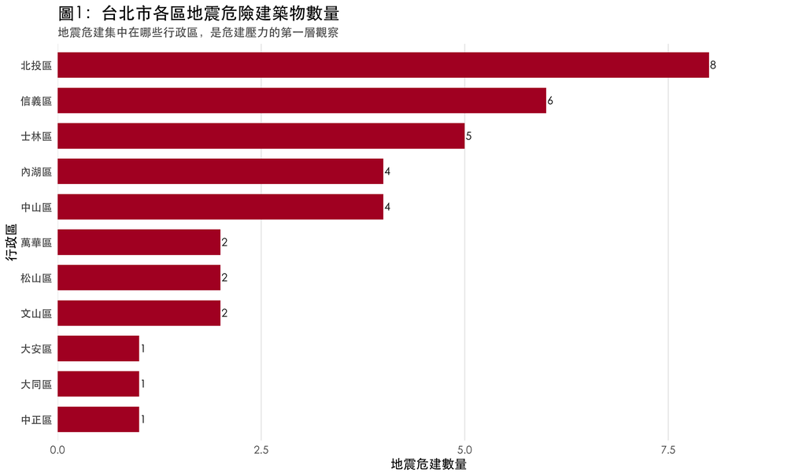

```r
earthquake_plot_data <- analysis_data |>
  filter(地震危建數 > 0) |>
  arrange(地震危建數)

ggplot(
  earthquake_plot_data,
  aes(x = reorder(district, 地震危建數), y = 地震危建數)
) +
  geom_col(fill = "#b2182b", width = 0.72) +
  geom_text(
    aes(label = comma(地震危建數)),
    hjust = -0.18,
    family = "STHeiti",
    size = 3.6
  ) +
  coord_flip() +
  scale_y_continuous(labels = comma, expand = expansion(mult = c(0, 0.14))) +
  labs(
    title = "圖1：台北市各區地震危險建築物數量",
    subtitle = "地震危建集中在哪些行政區，是危建壓力的第一層觀察",
    x = "行政區",
    y = "地震危建數量"
  )
```

以下程式碼繪製圖2：各區海砂屋數量長條圖，橘色代表海砂屋。

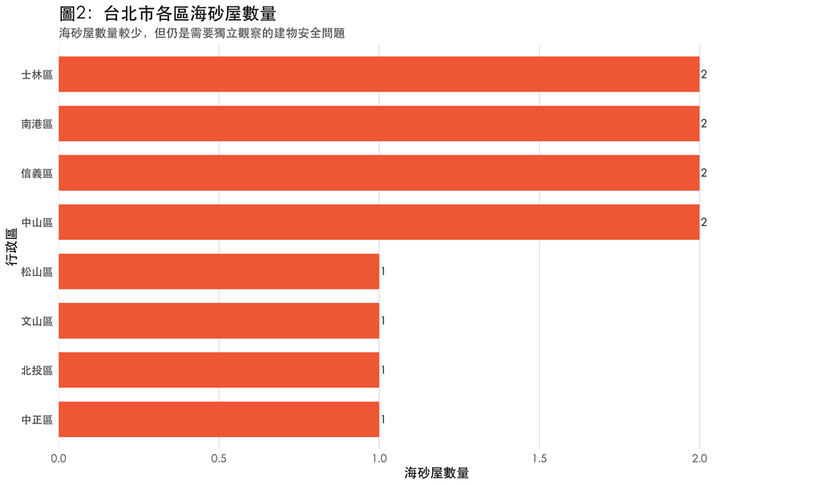

```r
chloride_plot_data <- analysis_data |>
  filter(海砂屋數 > 0) |>
  arrange(海砂屋數)

ggplot(
  chloride_plot_data,
  aes(x = reorder(district, 海砂屋數), y = 海砂屋數)
) +
  geom_col(fill = "#f46d43", width = 0.72) +
  geom_text(
    aes(label = comma(海砂屋數)),
    hjust = -0.18,
    family = "STHeiti",
    size = 3.6
  ) +
  coord_flip() +
  scale_y_continuous(labels = comma, expand = expansion(mult = c(0, 0.18))) +
  labs(
    title = "圖2：台北市各區海砂屋數量",
    subtitle = "海砂屋數量較少，但仍是需要獨立觀察的建物安全問題",
    x = "行政區",
    y = "海砂屋數量"
  )
```

以下程式碼繪製圖3：危建總數與都市更新案件數的並排長條圖，用來比較各區危建壓力與都更案件量。

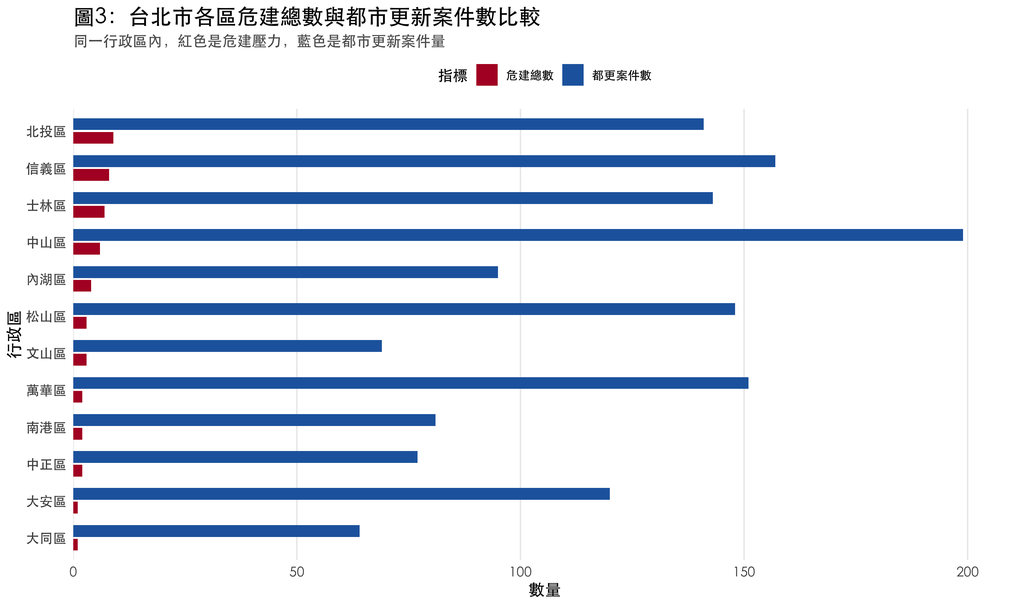

```r
district_order <- analysis_data |>
  arrange(危建總數) |>
  pull(district)

bar_compare_data <- analysis_data |>
  mutate(district = factor(district, levels = district_order)) |>
  select(district, 危建總數, 都更案件數) |>
  pivot_longer(
    cols = c(危建總數, 都更案件數),
    names_to = "指標",
    values_to = "數量"
  )

ggplot(
  bar_compare_data,
  aes(x = district, y = 數量, fill = 指標)
) +
  geom_col(position = position_dodge(width = 0.74), width = 0.64) +
  coord_flip() +
  scale_y_continuous(labels = comma, expand = expansion(mult = c(0, 0.06))) +
  scale_fill_manual(values = c("危建總數" = "#b2182b", "都更案件數" = "#2166ac")) +
  labs(
    title = "圖3：台北市各區危建總數與都市更新案件數比較",
    subtitle = "同一行政區內，紅色是危建壓力，藍色是都市更新案件量",
    x = "行政區",
    y = "數量",
    fill = "指標"
  )
```

並排比較最直觀地呈現本研究的單位落差問題：在所有行政區中，藍色長條（都更案件數）都遠高於紅色長條（危建總數）。這個視覺差距乍看像是「都更已嚴重超過危建」，但兩條長條的單位不同——一件都更案件可涵蓋多棟建物或整片基地，而危建總數則是逐棟列管的個別建物。因此圖 3 不應被解讀為「都更超前危建」，它的真正用途是提醒後續的追趕率指標必須放在相對尺度上理解。

以下程式碼繪製圖4：都更追趕率排名，紅色代表追趕率較低、綠色代表追趕率較高。

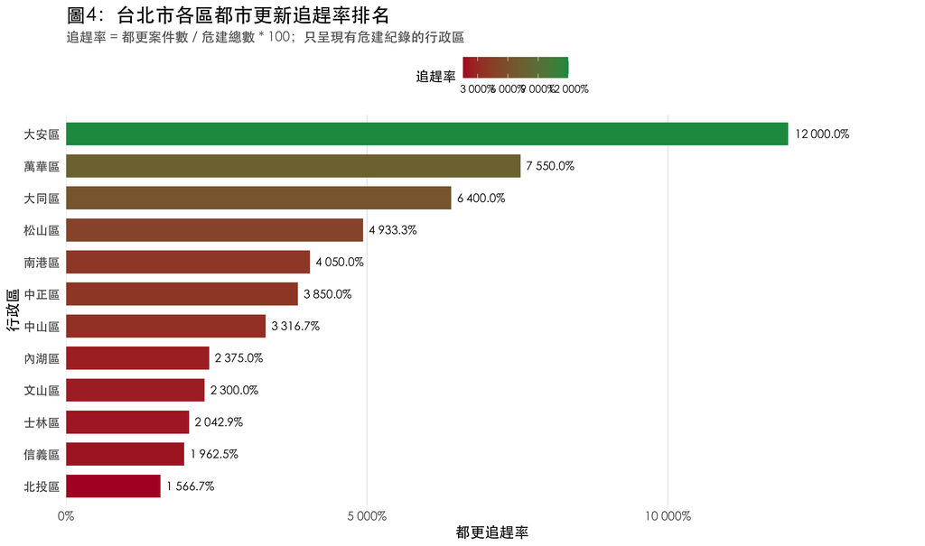

```r
catchup_plot_data <- analysis_data |>
  filter(危建總數 > 0, !is.na(都更追趕率)) |>
  arrange(都更追趕率)

ggplot(
  catchup_plot_data,
  aes(x = reorder(district, 都更追趕率), y = 都更追趕率, fill = 都更追趕率)
) +
  geom_col(width = 0.72) +
  geom_text(
    aes(label = percent(都更追趕率 / 100, accuracy = 0.1)),
    hjust = -0.12,
    family = "STHeiti",
    size = 3.4
  ) +
  coord_flip() +
  scale_y_continuous(labels = label_percent(scale = 1), expand = expansion(mult = c(0, 0.18))) +
  scale_fill_gradient(
    low = "#b2182b",
    high = "#1a9850",
    labels = label_percent(scale = 1)
  ) +
  labs(
    title = "圖4：台北市各區都市更新追趕率排名",
    subtitle = "追趕率 = 都更案件數 / 危建總數 * 100；只呈現有危建紀錄的行政區",
    x = "行政區",
    y = "都更追趕率",
    fill = "追趕率"
  )
```

追趕率排名顯示各區之間有明顯落差。最低者 **北投區**（1 566.7%）相對於該區 9 件危建，都更案件量是 12 區中相對最少的；最高者 **大安區**（12 000.0%）則是因為危建數極低（分母小）造成的極端值。換句話說，追趕率高並不必然代表「都更做得多」，也可能代表「危建少」；追趕率低也未必代表政策怠惰，而可能反映都更案件較少落在該區。真正值得關注的，是同時具有高危建總數與相對較低追趕率的區位，這類區位是後續政策盤點與資源配置的優先觀察對象。

以下程式碼繪製圖5：台北市危建建物地理分布地圖。底圖為 12 個行政區的真實邊界（資料來源：geoBoundaries TWN ADM2），紅色點為地震危建、橘色點為海砂屋。

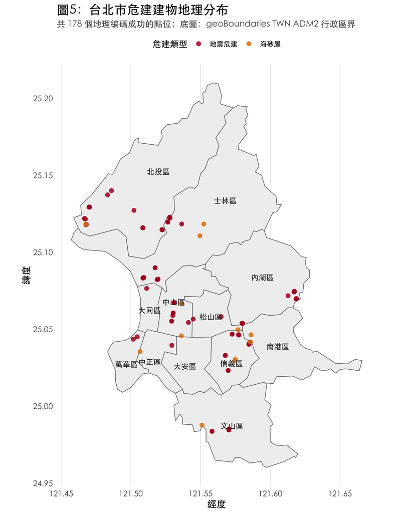

```r
flatten_coords <- function(x) {
  probe <- x
  while (is.list(probe) && length(probe) > 0) {
    first <- probe[[1]]
    if (is.numeric(first) && length(first) == 1) break
    probe <- first
  }
  dim_per_pt <- length(probe)
  if (dim_per_pt < 2) return(NULL)
  v <- unlist(x)
  if (length(v) %% dim_per_pt != 0) return(NULL)
  m <- matrix(v, ncol = dim_per_pt, byrow = TRUE)
  m[, 1:2, drop = FALSE]
}

fetch_hazard_points <- function(url, type_label) {
  resp <- request(url) |>
    req_perform() |>
    resp_body_json(simplifyVector = FALSE)

  rows <- list()
  for (feature in resp$features) {
    geom <- feature$geometry
    if (is.null(geom) || is.null(geom$coordinates)) next

    district <- feature$properties$district
    if (is.null(district)) district <- "未知區"

    coords_list <- if (geom$type == "MultiPoint") geom$coordinates else list(geom$coordinates)

    for (coord in coords_list) {
      if (length(coord) < 2) next
      lon <- coord[[1]]
      lat <- coord[[2]]
      if (is.null(lon) || is.null(lat)) next
      if (lon == 0 || lat == 0) next
      rows[[length(rows) + 1L]] <- data.frame(
        longitude = lon, latitude = lat,
        district = district, type = type_label
      )
    }
  }
  if (length(rows) == 0) return(NULL)
  do.call(rbind, rows)
}

fetch_district_polygons <- function(url) {
  resp <- request(url) |>
    req_perform() |>
    resp_body_json(simplifyVector = FALSE)

  poly_rows <- list()
  label_rows <- list()
  for (feature in resp$features) {
    name <- feature$properties$district
    label_rows[[length(label_rows) + 1L]] <- data.frame(
      district = name,
      longitude = feature$properties$label_lon,
      latitude = feature$properties$label_lat
    )

    geom <- feature$geometry
    polys <- if (geom$type == "Polygon") list(geom$coordinates) else geom$coordinates
    for (pi in seq_along(polys)) {
      ring <- polys[[pi]][[1]]
      m <- flatten_coords(ring)
      if (is.null(m) || nrow(m) == 0) next
      poly_rows[[length(poly_rows) + 1L]] <- data.frame(
        longitude = m[, 1], latitude = m[, 2],
        district = name,
        group_id = sprintf("%s-%d", name, pi)
      )
    }
  }
  list(
    polygons = do.call(rbind, poly_rows),
    labels = do.call(rbind, label_rows)
  )
}

hazard_points <- bind_rows(
  fetch_hazard_points(paste0(base_url, "/api/geojson/earthquake-buildings"), "地震危建"),
  fetch_hazard_points(paste0(base_url, "/api/geojson/chloride-ionized-concrete"), "海砂屋")
)

district_data <- fetch_district_polygons(paste0(base_url, "/api/geojson/taipei-districts"))
district_polys <- district_data$polygons
label_df <- district_data$labels

ggplot() +
  geom_polygon(
    data = district_polys,
    aes(x = longitude, y = latitude, group = group_id),
    fill = "gray94", color = "gray45", linewidth = 0.35
  ) +
  geom_point(
    data = hazard_points,
    aes(x = longitude, y = latitude, color = type),
    alpha = 0.85, size = 2.2
  ) +
  geom_text(
    data = label_df,
    aes(x = longitude, y = latitude, label = district),
    family = "STHeiti", color = "gray15", size = 3.4,
    fontface = "bold"
  ) +
  coord_quickmap() +
  scale_color_manual(values = c("地震危建" = "#b2182b", "海砂屋" = "#e08214")) +
  labs(
    title = "圖5：台北市危建建物地理分布",
    subtitle = paste0(
      "共 ", comma(nrow(hazard_points)), " 個地理編碼成功的點位；",
      "底圖：geoBoundaries TWN ADM2 行政區界"
    ),
    x = "經度",
    y = "緯度",
    color = "危建類型"
  )
```

地圖視角揭示行政區彙總所看不到的空間結構。地震危建並非平均散落，而是形成兩個明顯叢集：一個位於北投至士林一帶（地圖左上），另一個則在中山、松山、信義交界處（地圖中央偏南）。海砂屋（橘點）則零星散落於中山、南港等區，與地震危建的叢集位置部分接近但不完全重疊。這些建物熱點與行政區界並不一致，表示危建在實際空間上是跨區的帶狀問題，以行政區為單位的彙整可能會切割掉這個地理現象——這是本研究在使用「行政區為比較單位」時必須承認的空間粒度限制。

## 8 輸出乾淨資料

合併後的行政區層級分析資料以 CSV 格式輸出至 `Data/` 資料夾，檔名加上日期方便日後版本追蹤。各欄位的意義整理在專案根目錄的 `codebook.md`。

```r
if (!dir.exists("Data")) {
  dir.create("Data")
}

write_csv(analysis_data, "Data/clean_data_2026-05-08.csv")
```

## 9 結論

### 9.1 主要結果

本次分析共納入台北市地震危險建築物 36 筆、海砂屋 12 筆，合計危建 48 件；都市更新案件經行政區彙總後共 1,445 件，全市追趕率為 3 010.4%。

危建總數最多的行政區是 **北投區**，共有 **9** 件危建，其中地震危建 **8** 件、海砂屋 **1** 件；該區都市更新案件數為 **141** 件，追趕率為 **1 566.7%**。

在有危建紀錄的行政區中，都更追趕率最低的是 **北投區**（1 566.7%），代表相對於目前列管的危建數量，都更案件量最沒有跟上；追趕率最高的是 **大安區**（12 000.0%），但其極端高值是分母（危建總數）較小所致，並非單純代表都更施行得最積極。

第二，**都更案件數遠多於危建總數，但兩者單位不對等**。每個行政區的都更案件量（藍色長條，圖 3）皆遠高於該區危建總數（紅色長條），但這並非「都更已處理完所有危建」的意思。一件都更案件可涵蓋多棟建物，並橫跨從計畫核定到完工的不同階段，因此「都更案件數 / 危建總數」只能作為相對指標，不可解讀為實質處理進度。

第三，**地理叢集跨越行政區界**。圖 5 的地圖顯示危建建物在空間上形成兩個叢集：北投至士林一帶，以及中山、松山、信義交界處。這些熱點與行政區界並不一致，提示危建問題實際上是跨區的帶狀現象，以行政區為彙整單位雖便於政策對話，但會切割掉地理上的連續性。

### 9.3 限制與後續方向

本研究的限制有三：

1. 原始資料反映的是**現行列管狀態**，並非歷史累積；資料更新後，數值可能小幅變動。
2. 地址解析雖已涵蓋路、街、巷弄、範圍門牌、奇偶區段等多種寫法，仍可能在未來資料出現新格式時遺漏部分紀錄。
3. 都市更新案件數**無法區分**計畫核定、施工中與已完工等不同階段，因此追趕率僅能作為相對指標，不可解讀為實質處理進度；要進一步區分需要案件層級的進度欄位資料。

若後續能取得**都更案件的進度資料**（例如核定/施工/完工狀態）、以及**危建解列的歷史紀錄**，便可從目前的「相對指標」進階為「處理時序分析」，回答「危建被列管後幾年內進入都更？」這類更貼近政策目標的問題。在此之前，本研究的結論建議是：對同時具有較高危建總數與相對較低追趕率的行政區，列為政策盤點與資源配置的優先觀察區，並從跨區叢集的角度補強都市更新規劃。